# Problem

Job hunting is stressful for anyone entering the workforce. Candidates often struggle to determine the fair market value of their skills, while employers are in a stronger position with more information about prevailing salaries. This imbalance can leave job seekers at a disadvantage.

For this project, I focus specifically on Computer Science and Data Science graduates entering the job market. My aim is to analyze global salary data for Computer Science and Data Science related roles, with particular attention to entry-level positions. By examining salary patterns across job titles, I hope to highlight what recent graduates can realistically expect as they begin their careers and reduce some of the uncertainty that comes with negotiating a first job offer.

```python
import pandas as pd
import matplotlib.pyplot as plt
import seaborn as sns
```

# Data Set

Adil Shamim. Salaries for Data Science Jobs. Kaggle. Retrieved from https://www.kaggle.com/datasets/adilshamim8/salaries-for-data-science-jobs.

Scope. Global salary records across Data/ML/DE/Analytics roles with fields such as:

work_year – Year of salary report (int).

experience_level – e.g., EN (Entry), MI (Mid), etc.

employment_type – Full‑time/Contract/…

job_title – Free‑text; needs standardization.

salary & salary_currency – Raw compensation.

salary_in_usd – Converted salary in USD (use this for comparability).

employee_residence – ISO country.

company_location – Hiring company country.

company_size – S/M/L.

remote_ratio – % remote 0/50/100.

```python
data_path = "../data/salaries.csv"
```

# First Look

Nothing fancy, just loading the dataset and peeking at the first 5 rows. This quick glance helps me confirm the file loaded correctly and get a sense of the structure (columns, data types, and whether anything looks off right away).

```python
salaries_data = pd.read_csv(data_path)
salaries_data.head()
```

|  | work_year | experience_level | employment_type | job_title | salary | salary_currency | salary_in_usd | employee_residence | remote_ratio | company_location | company_size |
| --- | --- | --- | --- | --- | --- | --- | --- | --- | --- | --- | --- |
| 0 | 2025 | EX | FT | Head of Data | 348516 | USD | 348516 | US | 0 | US | M |
| 1 | 2025 | EX | FT | Head of Data | 232344 | USD | 232344 | US | 0 | US | M |
| 2 | 2025 | SE | FT | Data Scientist | 145400 | USD | 145400 | US | 0 | US | M |
| 3 | 2025 | SE | FT | Data Scientist | 81600 | USD | 81600 | US | 0 | US | M |
| 4 | 2025 | MI | FT | Engineer | 160000 | USD | 160000 | US | 100 | US | M |

# At the Beginning

Right away I noticed redundancy in the dataset: it included both salary and salary_currency, even though salary_in_usd was already standardized across all entries. To avoid confusion and keep only what was necessary, I dropped the extra columns. This left me with a cleaner dataset that focused on salaries in a consistent currency, making later comparisons more straightforward. The column names themselves looked good, ie. no extra spaces.

```python
salaries_data = salaries_data.drop(columns=["salary","salary_currency"])
print(salaries_data.columns)
```

```
Index(['work_year', 'experience_level', 'employment_type', 'job_title',
       'salary_in_usd', 'employee_residence', 'remote_ratio',
       'company_location', 'company_size'],
      dtype='object')
```

# Null

One of the first things I checked for was missing values. Surprisingly, there were no nulls in the dataset. While this doesn’t guarantee data quality, it at least meant I didn’t have to spend time filling gaps or making assumptions for missing entries. That let me move forward more quickly into cleaning and analysis.

```python
salaries_data.isnull().sum()
```

```
work_year             0
experience_level      0
employment_type       0
job_title             0
salary_in_usd         0
employee_residence    0
remote_ratio          0
company_location      0
company_size          0
dtype: int64
```

# Who's the Clone here?

Next I checked for duplicate rows, since repeated entries could artificially inflate salaries or distort frequency counts.

```python
salaries_data.shape
```

```
(151445, 9)
```

```python
salaries_data.duplicated().sum()
```

```
np.int64(79555)
```

# You're a clone. You're a clone! Everyone's a clone!

When I ran a duplicate check, I was shocked to see over 79,000 duplicates, more than half the dataset. That raised immediate red flags: if left unchecked, these repeats would heavily skew salary statistics and misrepresent job frequency.

To get a better sense of the issue, I sorted the data and looked through a sample of 50 rows, so I could confirm that the duplicates weren’t subtle variations but exact repeats.

```python
salaries_data.sort_values("job_title", ascending=False).head(50)
```

|  | work_year | experience_level | employment_type | job_title | salary_in_usd | employee_residence | remote_ratio | company_location | company_size |
| --- | --- | --- | --- | --- | --- | --- | --- | --- | --- |
| 14955 | 2025 | SE | FT | Web Developer | 142000 | US | 0 | US | M |
| 31152 | 2025 | SE | FT | Web Developer | 169000 | US | 0 | US | M |
| 14954 | 2025 | SE | FT | Web Developer | 150000 | US | 0 | US | M |
| 26252 | 2025 | SE | FT | Web Developer | 120000 | US | 100 | US | M |
| 35304 | 2025 | MI | FT | Web Developer | 153925 | US | 0 | US | M |
| 35305 | 2025 | MI | FT | Web Developer | 85150 | US | 0 | US | M |
| 31153 | 2025 | SE | FT | Web Developer | 109400 | US | 0 | US | M |
| 36969 | 2025 | EN | FT | Web Developer | 22584 | CZ | 50 | CZ | M |
| 26251 | 2025 | SE | FT | Web Developer | 142000 | US | 100 | US | M |
| 32165 | 2025 | EN | FT | Trainee | 50000 | US | 0 | US | M |
| 7646 | 2025 | EN | FT | Trainee | 18402 | CZ | 0 | CZ | M |
| 41009 | 2025 | EN | FT | Trainee | 50000 | US | 0 | US | M |
| 34634 | 2025 | EN | FT | Trainee | 61427 | NL | 0 | NL | M |
| 32164 | 2025 | EN | FT | Trainee | 56000 | US | 0 | US | M |
| 7647 | 2025 | EN | FT | Trainee | 18402 | CZ | 0 | CZ | M |
| 37972 | 2025 | EN | FT | Trainee | 77894 | DE | 0 | DE | M |
| 37973 | 2025 | EN | FT | Trainee | 71578 | DE | 0 | DE | M |
| 34635 | 2025 | EN | FT | Trainee | 61427 | NL | 0 | NL | M |
| 46627 | 2025 | EN | FT | Trainee | 68000 | US | 0 | US | M |
| 46628 | 2025 | EN | FT | Trainee | 46000 | US | 0 | US | M |
| 41008 | 2025 | EN | FT | Trainee | 56000 | US | 0 | US | M |
| 65013 | 2025 | MI | FT | Technology Integrator | 60300 | US | 0 | US | M |
| 65010 | 2025 | MI | FT | Technology Integrator | 137000 | US | 0 | US | M |
| 83729 | 2024 | MI | FT | Technology Integrator | 137000 | KR | 0 | KR | M |
| 83731 | 2024 | MI | FT | Technology Integrator | 137000 | DE | 0 | DE | M |
| 83732 | 2024 | MI | FT | Technology Integrator | 60300 | DE | 0 | DE | M |
| 65012 | 2025 | MI | FT | Technology Integrator | 137000 | US | 0 | US | M |
| 65011 | 2025 | MI | FT | Technology Integrator | 60300 | US | 0 | US | M |
| 73833 | 2025 | MI | FT | Technology Integrator | 137000 | DE | 0 | DE | M |
| 83733 | 2024 | SE | FT | Technology Integrator | 137000 | US | 0 | US | M |
| 83734 | 2024 | SE | FT | Technology Integrator | 60300 | US | 0 | US | M |
| 73834 | 2025 | MI | FT | Technology Integrator | 60300 | DE | 0 | DE | M |
| 83730 | 2024 | MI | FT | Technology Integrator | 60300 | KR | 0 | KR | M |
| 77164 | 2025 | MI | FT | Technical Writer | 102000 | US | 0 | US | M |
| 81428 | 2024 | SE | FT | Technical Writer | 90480 | US | 100 | US | M |
| 77163 | 2025 | MI | FT | Technical Writer | 150000 | US | 0 | US | M |
| 31164 | 2025 | MI | FT | Technical Writer | 144660 | US | 100 | US | M |
| 31165 | 2025 | MI | FT | Technical Writer | 90480 | US | 100 | US | M |
| 94464 | 2024 | MI | FT | Technical Writer | 80000 | US | 0 | US | M |
| 86870 | 2024 | SE | FT | Technical Writer | 100000 | US | 0 | US | M |
| 86869 | 2024 | SE | FT | Technical Writer | 500000 | US | 0 | US | M |
| 97609 | 2024 | MI | FT | Technical Writer | 114800 | US | 100 | US | M |
| 97608 | 2024 | MI | FT | Technical Writer | 135000 | US | 100 | US | M |
| 77593 | 2025 | SE | CT | Technical Writer | 100000 | US | 0 | US | M |
| 77592 | 2025 | SE | CT | Technical Writer | 500000 | US | 0 | US | M |
| 31087 | 2025 | SE | FT | Technical Writer | 128000 | US | 0 | US | M |
| 31086 | 2025 | SE | FT | Technical Writer | 160000 | US | 0 | US | M |
| 1577 | 2025 | SE | FT | Technical Writer | 104080 | US | 100 | US | M |
| 50867 | 2025 | SE | FT | Technical Writer | 171000 | US | 0 | US | M |
| 81427 | 2024 | SE | FT | Technical Writer | 144660 | US | 100 | US | M |

# To drop or not to drop, that is the question

After digging deeper, it turned out those 79,000 “duplicates” weren’t actually duplicates at all. The dataset doesn’t include strong identifying keys, so many rows look identical at first glance but likely represent separate records. With that in mind, I decided to keep them, assuming the dataset already accounts for duplicates in its own way.

But this led me straight into another red flag. I noticed that Technical Writers were listed with top salaries approaching $500,000. A quick reality check showed this is highly unlikely. Clearly, not every anomaly in this dataset can be brushed aside so easily.

```python
salaries_data[salaries_data['job_title'].str.contains('Technical Writer')]["salary_in_usd"].sort_values(ascending=False).head(50)
```

```
48007    500000
86033    500000
86869    500000
77592    500000
4089     365000
4090     250000
765      189000
51031    173800
50867    171000
95978    171000
1576     166320
31086    160000
77163    150000
81427    144660
31164    144660
```

[output cut: 23 more lines]

# Red Flags

Technical Writer listed with a salary of `$500,000` was the canary in the coal mine that suggested something was wrong. To investigate further, I pulled the top 30 salaries by job title, and the results confirmed my suspicions: analysts, engineers, and other roles had reported salaries far beyond realistic market values (some approaching 800k).

These outliers are highly unlikely to be accurate. They distort the dataset, making it impossible to draw reliable insights.

Next step: remove these implausible entries. I chose to drop all salaries above `$300,000`, which preserves legitimate high-paying executive roles while discarding extreme and likely erroneous values.

```python
top_salaries_all = (
    salaries_data.groupby('job_title')['salary_in_usd']
    .max()
    .sort_values(ascending=False)
)

# Show top 30
top_salaries_all.head(30)
```

```
job_title
AI Architect                        800000
Architect                           800000
Software Engineer                   800000
Data Engineer                       793136
Data Analyst                        774000
Machine Learning Scientist          750000
Data Scientist                      750000
Machine Learning Engineer           750000
Analytics Engineer                  750000
Research Engineer                   750000
Product Manager                     725000
Site Reliability Engineer           720000
Backend Engineer                    720000
Research Scientist                  720000
Systems Engineer                    720000
Data Visualization Engineer         720000
ML Infrastructure Engineer          643750
Data Specialist                     632911
Manager                             632911
Engineering Manager                 625000
Engineer                            625000
Head of Data                        625000
AI Scientist                        609200
Analyst                             600702
Prompt Engineer                     600000
AI Engineer                         600000
Product Owner                       598952
Principal Statistical Programmer    597478
Insight Analyst                     592500
Research Team Lead                  560000
Name: salary_in_usd, dtype: int64
```

# Removing the Skew

After reviewing the dataset, I identified several unrealistic salary values (e.g., entry-level roles exceeding `$500k`). To address this, I set $300k as a reasonable upper limit and removed any entries above that threshold.

When comparing before and after, the data distribution is much tighter. Most salaries now fall between `$100k` and `$200k`, which aligns more closely with expectations.

However, this view still represents the entire dataset across all experience levels.

```
Original dataset size: 151445
Cleaned dataset size: 145699
Rows dropped: 5746
```

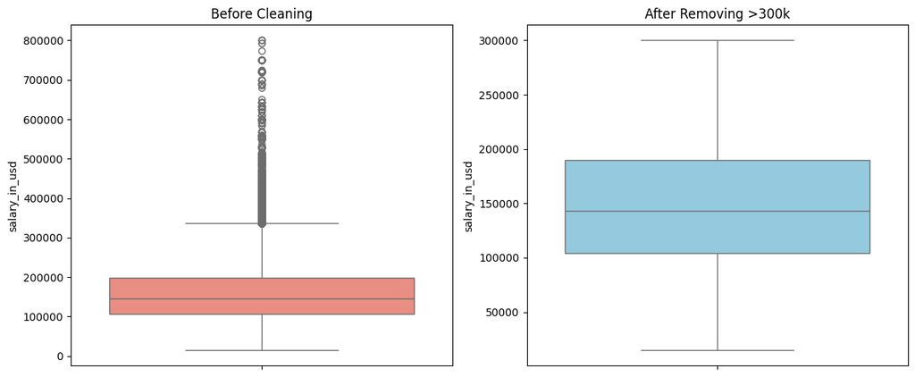

```python
salaries_clean = salaries_data[salaries_data['salary_in_usd'] <= 300000].copy()

print("Original dataset size:", len(salaries_data))
print("Cleaned dataset size:", len(salaries_clean))
print("Rows dropped:", len(salaries_data) - len(salaries_clean))

fig, axes = plt.subplots(1, 2, figsize=(12, 5))

sns.boxplot(y=salaries_data['salary_in_usd'], ax=axes[0], color="salmon")
axes[0].set_title("Before Cleaning")

sns.boxplot(y=salaries_clean['salary_in_usd'], ax=axes[1], color="skyblue")
axes[1].set_title("After Removing >300k")

plt.tight_layout()
plt.show()
```

# Initial visualization of dataset

Looking at the salaries for the top 25 entry-level roles (EN) revealed inconsistencies between job titles and experience levels. For example, “Engineering Manager” and “Director” appeared under entry-level positions, which is not realistic.

This suggests the dataset contains mislabeled rows, where leadership or executive titles were incorrectly assigned to the entry-level category. Such anomalies can distort median salary analysis for EN roles, so we need to apply additional preprocessing to filter them out.

[figure not shown]

```python
level = "EN"
df_level = salaries_clean[salaries_clean['experience_level'] == level]

# Get top 15 job titles by median salary
agg = (df_level.groupby('job_title')['salary_in_usd']
       .median()
       .sort_values()
       .tail(25))

fig, ax = plt.subplots(figsize=(10, 6))
agg.plot(kind='barh', ax=ax, color='skyblue')

ax.set_xlabel("Median Salary (USD)")
ax.set_ylabel("Job Title")
ax.set_title(f"Top 15 Job Titles by Median Salary ({level} Level)")
ax.grid(axis='x', linestyle='--', alpha=0.5)
plt.tight_layout()
plt.show()
```

# Further Data Preprocessing

At this stage, I reviewed all unique job titles to better understand the dataset. My concern was that some legitimate entry-level roles might contain keywords such as “Manager” or “Lead”, for example, Data Manager or Research Data Manager.

If I had dropped all job titles containing “Manager” outright, I would have incorrectly removed valid entry-level positions. Therefore, I chose to first generate a list of flagged titles, review them manually, and then apply a refined filter. This ensures that I only remove mislabeled rows (e.g., “Entry-level Director” or “Entry-level Engineering Manager”) while preserving legitimate roles.

```python
unique_titles = salaries_clean['job_title'].unique()
print("Number of unique titles:", len(unique_titles))
for title in sorted(unique_titles):
    print(title)
```

```
Number of unique titles: 419
AI Architect
AI Content Writer
AI Data Engineer
AI Data Scientist
AI Developer
AI Engineer
AI Engineering Lead
AI Engineering Manager
AI Governance Lead
AI Governance Specialist
AI Lead
AI Machine Learning Engineer
AI Product Lead
AI Product Manager
AI Product Owner
AI Product Specialist
AI Programmer
AI Research Engineer
AI Research Scientist
AI Researcher
AI Scientist
AI Software Development Engineer
AI Software Engineer
AI Solution Architect
AI Solution Director
AI Solutions Consultant
AI Solutions Lead
AI Solutions Specialist
AI Specialist
AI Strategist
AI Tech Lead
AIRS Solutions Specialist
AWS Data Architect
Account Executive
Actuarial Analyst
Actuary
Admin & Data Analyst
Advanced Analytics Manager
Advanced Data Analyst
```

[output cut: 365 more lines]

```
Tableau Developer
Tech Lead
Tech Lead Data
Technical Architect
Technical Consultant
Technical Lead
Technical Project Manager
Technical Recruiter
Technical Specialist
Technical Support Engineer
Technical Support Specialist
Technical Writer
Technology Integrator
Trainee
Web Developer
```

# Clean point

At this stage, I separated leadership roles (titles containing words like Manager, Director, Head, Lead, etc.) from non-leadership roles. The reasoning is that some job titles in the dataset are mislabeled as entry level (EN) even though they are clearly management positions. Including those would artificially inflate entry-level salary estimates.

By splitting these groups, I can better focus on the roles that are realistic for new graduates, while still keeping transparency about what data was excluded. This step is part of the preprocessing process and ensures that the analysis reflects a more accurate picture of true entry-level opportunities.

```python
keywords = ["head", "manager", "director", "lead", "chief", "vp"]
mask = salaries_clean['job_title'].str.contains("|".join(keywords), case=False, na=False)

leadership_roles = salaries_clean[mask]
non_leadership_roles = salaries_clean[~mask]

print("Leadership/Managerial titles:", leadership_roles['job_title'].nunique())
print("Non-leadership titles:", non_leadership_roles['job_title'].nunique())
```

```
Leadership/Managerial titles: 78
Non-leadership titles: 341
```

# Clean Visualization

While the chart does show which jobs can pay the most, it still emphasizes the top of the distribution. This is less helpful for answering the project’s central question: what salary can a typical new graduate expect? To get at that, I need to shift focus from the top-paying roles to the overall salary distribution across all entry-level positions.

[figure not shown]

```python
# Get top 15 job titles by median salary
agg = (non_leadership_roles.groupby('job_title')['salary_in_usd']
       .median()
       .sort_values()
       .tail(15))

# Plot
fig, ax = plt.subplots(figsize=(10, 6))
agg.plot(kind='barh', ax=ax, color='skyblue')

ax.set_xlabel("Median Salary (USD)")
ax.set_ylabel("Job Title")
ax.set_title(f"Top 15 Non-Leadership Job Titles by Median Salary ({level} Level)")
ax.grid(axis='x', linestyle='--', alpha=0.5)
plt.tight_layout()
plt.show()
```

# Double check

```python
# List unique titles that would be dropped
bad_titles = salaries_clean.loc[mask, 'job_title'].unique()
print("Unique EN titles flagged for removal:")
for t in sorted(bad_titles):
    print("-", t)

# Optional: show counts per title
print("\nCounts per title:")
print(salaries_clean.loc[mask, 'job_title'].value_counts())
```

```
Unique EN titles flagged for removal:
- AI Engineering Lead
- AI Engineering Manager
- AI Governance Lead
- AI Lead
- AI Product Lead
- AI Product Manager
- AI Solution Director
- AI Solutions Lead
- AI Tech Lead
- Advanced Analytics Manager
- Analytics Lead
- Analytics Manager
- Applied AI ML Lead
- Business Development Manager
- Business Insights Manager
- Business Intelligence Lead
- Business Intelligence Manager
- Customer Success Manager
- Data Analyst Lead
- Data Analytics Lead
- Data Analytics Manager
- Data Analytics Team Lead
- Data Governance Lead
- Data Governance Manager
- Data Integration Lead
- Data Lead
- Data Management Lead
- Data Management Manager
- Data Manager
- Data Operations Lead
- Data Operations Manager
- Data Product Lead
- Data Product Manager
- Data Quality Lead
- Data Quality Manager
- Data Scientist Lead
- Data Scientist Manager
- Data Strategy Lead
- Data Strategy Manager
```

[output cut: 39 more lines]

```

Counts per title:
job_title
Manager                         7506
Product Manager                 2391
Data Manager                    1073
Director                         700
Engineering Manager              683
                                ...
Customer Success Manager           1
AI Engineering Lead                1
Business Development Manager       1
Applied AI ML Lead                 1
Lead AI Engineer                   1
Name: count, Length: 78, dtype: int64
```

# On with the Show

Here I plot two graphs to better understand the distribution of entry-level salaries.

Boxplot: This shows the spread and quartiles. The median is around 86k, with most of the data falling between 60k and 120k. At first glance, one might assume that 86k is the “expected” salary.

```
Entry-level dataset size: 13571
Median EN salary: 86100.0
```

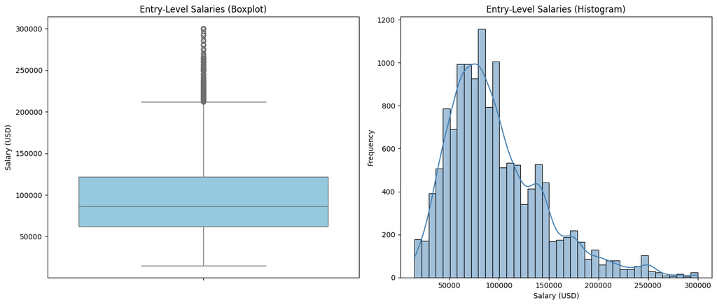

```python
df_en_nonlead = salaries_clean[salaries_clean['experience_level'] == 'EN']

print("Entry-level dataset size:", len(df_en_nonlead))
print("Median EN salary:", df_en_nonlead['salary_in_usd'].median())

fig, axes = plt.subplots(1, 2, figsize=(14, 6))

# Boxplot
sns.boxplot(y=df_en_nonlead['salary_in_usd'], ax=axes[0], color="skyblue")
axes[0].set_title("Entry-Level Salaries (Boxplot)")
axes[0].set_ylabel("Salary (USD)")

# Histogram
sns.histplot(df_en_nonlead['salary_in_usd'], bins=40, kde=True, ax=axes[1], color="steelblue")
axes[1].set_title("Entry-Level Salaries (Histogram)")
axes[1].set_xlabel("Salary (USD)")
axes[1].set_ylabel("Frequency")

plt.tight_layout()
plt.show()
```

# Feeling the Heat

To understand where these jobs are located and how salaries vary by region, I used a heat map. The visualization shows a clear concentration of both the number of jobs and the highest salaries in the United States.

This finding raises an important caveat: the dataset appears to be skewed toward U.S. data, which may inflate global salary expectations.

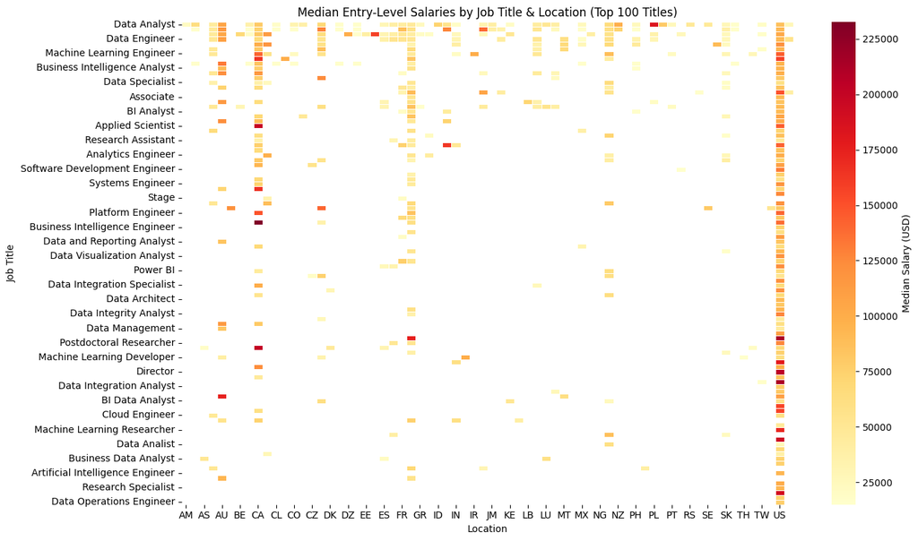

```python
# Median salary by job title and location
pivot_job_loc = (
    df_en_nonlead.pivot_table(
        values='salary_in_usd',
        index='job_title',
        columns='company_location',
        aggfunc='median'
    )
)

# Focus on top 100 job titles by count for readability
top_jobs = df_en_nonlead['job_title'].value_counts().head(100).index
pivot_job_loc = pivot_job_loc.loc[top_jobs]

plt.figure(figsize=(14, 8))
sns.heatmap(
    pivot_job_loc,
    cmap="YlOrRd",
    linewidths=0.5,
    annot=False,
    fmt=".0f",
    cbar_kws={'label': 'Median Salary (USD)'}
)
plt.title("Median Entry-Level Salaries by Job Title & Location (Top 100 Titles)")
plt.xlabel("Location")
plt.ylabel("Job Title")
plt.tight_layout()
plt.show()
```

# Reducing the Temp

The heatmap raised a question: is the dataset disproportionately U.S.-centric? To test this, I broke the data down by country and counted the number of entries.

The result confirmed my suspicion — the dataset is heavily skewed toward the United States, with far fewer entries from other countries. This imbalance explains why the U.S. dominates the heatmap and why global salary insights from this dataset must be treated with caution.

```python
country_counts = salaries_clean['company_location'].value_counts()

print(country_counts.head(20))  # top 20 countries
```

```
company_location
US    129993
CA      6164
GB      4083
AU       587
NL       481
DE       451
FR       436
LT       371
AT       353
ES       307
SK       248
IN       237
PL       166
IE       146
LV       118
BR       111
MX       111
AR        86
PT        85
FI        82
Name: count, dtype: int64
```

# Grain of Salt

The dataset is large, but not comprehensive. Many assumptions had to be made and several anomalies corrected, so confidence in the results is not absolute. Still, it provides a meaningful snapshot of the job market.

This analysis focuses specifically on entry-level salaries and posting frequency. A fuller picture would require additional context, such as job descriptions, company size, industry, and cost-of-living adjustments. Without these factors, the data can be misinterpreted. For instance, graduates outside the U.S. could be misled by the heavy U.S. skew and expect salaries that don’t match their local markets. Additionally because the analysis is not broken down by specific job title, salary expectations may vary significantly across roles. What this project offers is not a definitive answer, but a broad directional view of what entry-level compensation may look like.

This is a very broad look as this dataset spans 5 years worth of data and I do not breakdown jobs specifically. One can be misled to believe that alot of jobs offer the median range when it is only a certain type that offers that. This is intended to get a feel only.

# Closing Time

While this dataset is not perfect, it still equips graduates with a stronger sense of what to expect as they enter the job market. More importantly, it gives them leverage in negotiations — a clearer idea of the going rate for their skills and the confidence to push for compensation that reflects the true market.

# References

Shamim, A. (n.d.). Salaries for Data Science Jobs. Kaggle. Retrieved from  
https://www.kaggle.com/datasets/adilshamim8/salaries-for-data-science-jobs

# Disclaimer

Portions of the code refinement, data exploration, and narrative structuring were assisted by OpenAI’s ChatGPT (GPT-5). I directed the analysis, made final decisions on preprocessing steps, and selected visualizations, while ChatGPT was used as a learning and drafting tool.